# Technische Informatik

Architecture Inception Canvas und Quality Requirements

Author

Affiliation

Prof. Johannes Baumgartl

Hochschule Esslingen

Published

August 11, 2025

# 1 Architecture Inception Canvas, Quality Requirements und Fitnessfunktionen

Lernziele dieser Vorlesungseinheit:

- Methodik zum Strukturellen Aufbau eines Software Projekts anwenden können.
- Zusammenhang zwischen Zielen, Lösungen und der Bewertung eines Software-Projektes kennen.
- Funktionale Anforderungen und Quality Scenarios formulieren können.
- Werkzeuge für die Bewertung und Evaluation von Software-Projekten kennen.

## 1.1 Motivation

[figure not shown]

Motivation

Es ist eine Herausforderung aus den Wünschen und Ideen umsetzbare, verständliche, vollständige, … Anforderungen zu erzeugen. Diese Anforderungen und Klarheit über ein Softwareprojekt führt dann in letzter Konsequenz zu einer Wertschöpfung.

### 1.1.1 Aus Sicht von technischen Rollen

Häufig wird sofort in Lösungen und technischen Fragestellungen gedacht, wenn ein neues IT-Projekt / Produkt gebaut werden soll.

Zum Beispiel aus Entwicklerperspektive:

- Welche Programmiersprache sollen wir einsetzen?
- Sollen wir Technologie “xy” verwenden?
- Nehmen wir Docker?
- Nehmen wir eine Mirco-Service Architektur?

**Die meisten Teams tappen immer wieder in die gleiche Falle:**

Die Diskussion um die neusten technischen Lösungen und die low-level Architektur!

Solange das Spielfeld für die Gestaltung der Lösung nicht bekannt ist, sind zu tiefe technische Diskussionen nutzlos und Zeitverschwendung.

## 1.2 Architecture Inception Canvas oder Software Architecture Canvas

Der Architecture Inception Canvas ist ein übersichtlicher Ansatz, um die Ziele, Lösungsmöglichkeiten und Bewertungen für ein neues Software-Projekt zu erarbeiten.

Es ist um folgende 3 Leitfragen aufgebaut:

- Ziele: Was soll die Software tun?
- Lösungen: Wie können wir es erreichen?
- Bewertung: Wie evaluieren wir das Software-Projekt?

**Ziele in diesem Kontext**

beschreiben die relevanten Anforderungen und die treibenden Kräfte, die Softwarearchitekten und Entwicklungsteam berücksichtigen müssen. Dazu gehören

- zugrundeliegende Geschäftsziele, wesentliche Merkmale und funktionale Anforderungen für das System,
- Qualitätsziele für die Architektur,
- relevante Interessengruppen und ihre Erwartungen

Download: architecture-inception-canvas Quelle: https://canvas.arc42.org/

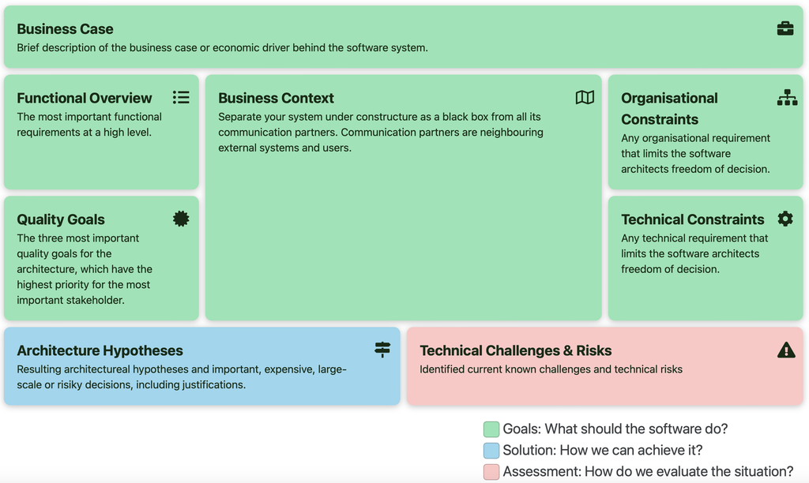

architecture-inception-canvas Quelle: https://canvas.arc42.org/

### 1.2.1 Business Case: Here is your WHY

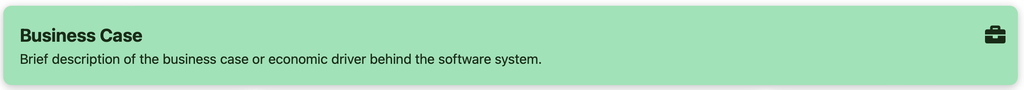

Inception Canvas - Business Case

Wenn das Unternehmen Geld verdienen muss, steht hinter jeder Softwareinitiative ein Business Case. Wenn nicht, ist es ein Hobby.

**Fallstrick**

Ein häufiger Fallstrick ist, dass das Entwicklungsteam, oder schlimmer noch, das gesamte Produktteam, den Business Case hinter der Softwareinitiative nicht kennt.

Wenn Sie als Teammitglied den Business Case hinter der Softwareinitiative nicht kennen oder nicht erklären können, dann sind Sie oft nicht in der Lage, ein sinnvolles Spielfeld für Ihre Softwarearchitektur zu definieren, weil Sie nicht wissen, was Sie für Ihr Unternehmen erreichen wollen.

**Business Case als Grundlage für die Entscheidungsfähigkeit und Intrinsische Motivation**

Es ist essenziell, dass jedes Teammitglied die wirtschaftlichen Triebfeder kennt und den Business Case hinter einer Softwareinitiative erklären kann, um Entscheidungen bei der Realisierung des Software-Produkts treffen zu können.

Der Business Case macht sich an folgenden Fragen fest:

- Was sind die wichtigsten Funktionen, Merkmale oder Anwendungsfälle des Systems?
- Welche Aktivitäten oder Prozesse bietet es?
- Welches ist der wichtigste Anwendungsfall?
- Welche der Funktionen sind für die Beteiligten von hohem Wert?
- Welche Funktionen sind riskant, gefährlich oder kritisch?

### 1.2.2 Functional Overview: This is your product box

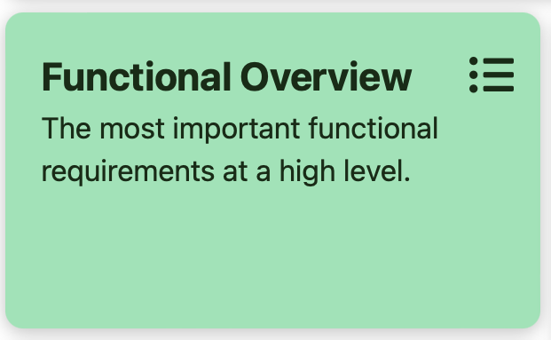

Inception Canvas - Functional Overview

Während Sie als Produktteam den funktionalen Überblick über die Software-Initiative erarbeiten, stellen Sie sich eine Produktbox Ihrer Software vor - was befindet sich auf Ihrer Softwarebox?

[figure not shown]

Front- und Rückseite - Was ist Drin?

[figure not shown]

Klappe - Was sind die wichtigsten Funktionen?

Figure 1: Leitfrage: What is on your software product box? am Beispiel eines Lego Sets

Denken Sie über das Produkt nach, um Antworten auf die folgenden Fragen zu erhalten:

- Welchen Geschäftswert (eng. business value) liefert die Software?
- Was sind die übergeordneten Anforderungen?

Beispielformat: eine einfache Tabelle mit Prioritäten 1-x.

| Priorität | Übergeordnete Anforderung |
| --- | --- |
| 1 |  |
| 2 |  |
| 3 |  |
| 4 |  |

*Die Definition der funktionalen Anforderungen* ist ein *obligatorischer Schritt im Softwareentwicklungsprozess*. Diese Anforderungen stammen in der Regel aus Anwendungsfällen, die von den **künftigen Betreibern** der zu entwickelnden Lösung **festgelegt** werden. Das **Entwicklungsteam** analysiert diese Fälle, **ordnet** **sie den Softwarefunktionen** zu und **bestimmt die erforderlichen Implementierungstechnologien**.

Es gibt mehrere Kategorien von funktionalen Anforderungen. Unter ihnen sind die folgenden Kategorien hervorzuheben (unvollständige Liste):

- **Authentifizierung**: bezieht sich auf die Art und Weise der Identifizierung eines Bedieners oder sogar von Informationen in den entwickelten Lösungen und Systemen
- **Berechtigungsstufen**: bezieht sich auf die unterschiedlichen Privilegien und Beschränkungen, die für die Betreiber gelten. So wird beispielsweise festgelegt, wer CRUD-Operationen (Ändern, Lesen, Aktualisieren oder Löschen) in der Lösung ausführen darf.
- **Externe Schnittstellen**: betrifft die externen Schnittstellen einer Lösung, die ihre Kommunikation mit anderen Lösungen, Systemen und Benutzern ermöglichen
- **Transaktionsverarbeitung**: betrifft die Art und Weise, wie Transaktionen analysiert und bearbeitet werden, z. B. das Eingeben, Ändern, Löschen und Stornieren
- **Compliance**: bezieht sich auf die Gesetze, Vorschriften und Richtlinien, die die Organisation, in der die Softwarelösung eingesetzt wird, befolgen muss
- **Datenbank**: bezieht sich auf die zu speichernden Daten und die dafür erforderlichen Formatierungsregeln

Sonstiges: Sicherung, Wiederherstellung, Verfügbarkeit, …

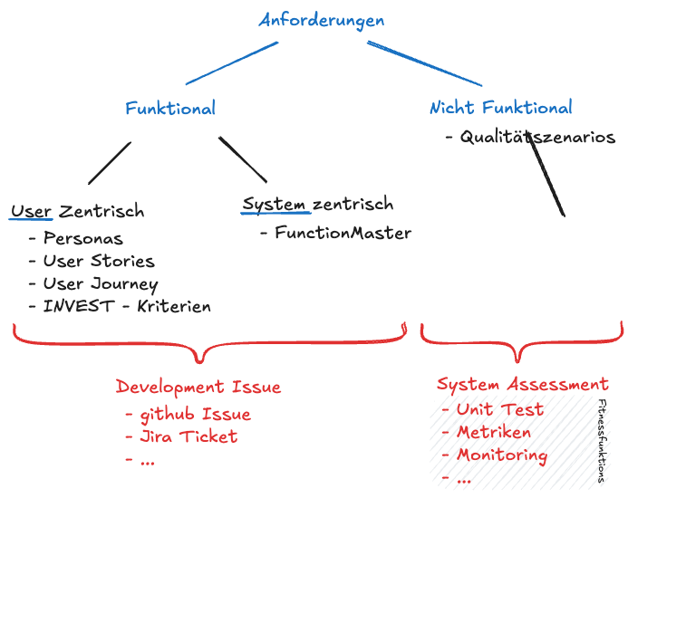

Strukturierung von Anforderungen

#### 1.2.2.1 Anforderungen: Persona und User Story

Die Persona ist ein häufig genutztes zentrales Konzept, um die User eines Systems zu abstrahieren.

**Persona**

Personas repräsentieren ein **breites Spektrum** an **Nutzertypen** und helfen dabei, die verschiedenen **Anforderungen und Wünsche** an Software-Systeme zu verstehen und zu adressieren. Sie werden durch einen kurzen stereotypischen Steckbrief beschrieben. Der Steckbrief beinhaltet einen Namen und listet relevante Eigenschaften (z.B. Alter, Bedürfnisse, Beruf, Herkunft …) auf.

**Übung: Personas für die Hochschule erstellen**

**a)** Suchen sie sich einen Partner für diese Aufgabe.

**b)** Teil b) Erstellen sie Personas für die Hochschule. Geben sie diesen einen Vornamen und relevante Eigenschaften, so dass sie eine Vorstellung für diese Person haben.

**Lösung: Personas für die Hochschule erstellen**

Heidi

- Alter: 53
- Hat 2 erwachsene Kinder
- Beruf: Mensamitarbeiterin
- Wünsche: Will schon immer mal nach Neuseeland fahren
- Hat ein Smartphone, um mit ihren Kindern zu chatten

Die User Story ist eine beliebte Methode um Funktionale Anforderungen zu formulieren.

**User Story**

Eine User Story ist eine Anforderung, die aus der Perspektive eines Endbenutzerziels ausgedrückt wird. User Stories können auch als Epics, Themes oder Features bezeichnet werden, folgen aber alle dem gleichen Format.

Eine User Story ist eine strukturiert ausgedrückte Anforderung. Das User-Story-Format ist aus mehreren Gründen die beliebteste Art, Anforderungen in Agile auszudrücken:

- Sie konzentriert sich auf die Sichtweise einer Rolle, die die Lösung nutzen wird oder von ihr betroffen ist.
- Sie definiert die Anforderung in einer Sprache, die für diese Rolle von Bedeutung ist.
- Es hilft, den wahren Grund für die Anforderung zu klären
- Es hilft dabei, Anforderungen auf hoher Ebene zu definieren, ohne notwendigerweise zu früh ins Detail gehen zu müssen.

**User Story Template**

“Als **Persona** **[möchte]** ich, **[damit]**.”

- “Als **[Persona/Rolle]**”: Für wen entwickeln wir? Z.B. Besucher der HS
- “**[Möchte]**”: Damit beschreiben wir die Absicht – und nicht die Funktionen, die der Benutzer verwendet. Welchen Zweck möchte der Kunde eigentlich erreichen? Z.B. von dem Roboterhund geführt warden.
- “**[Damit]**”: Wie passt der unmittelbare Wunsch des Kunden, etwas tun zu können, in sein Gesamtbild? Von welchem Nutzen möchte er allgemein gesehen profitieren? Welches große Problem muss hier gelöst werden? z.B. damit ich zum Raum G 04.208 finde.

**Beispiel User Story für Abbildung Figure 1**

Mögliche übergeordnete Anforderung: Das Set soll ein Bauerlebnis für die Familie (Eltern und Kinder) darstellen.

**Abgeleitete exemplarische Personas:**

- Tim der 12 jährige Junge, mag Technik und baut gerne, hat aber keine Geduld.
- Julia die 9 jährige Tochter, ist technikbegeistert und knobelt gerne.
- Eltern haben einen technischen Hintergrund und wollen auch selbst bauen.

**Abgeleitete exemplarische User Stories:**

- Für Julia und Tim muss die Anleitung so gestaltet sein, dass maximal 4 Teile pro Bauschritt verbaut werden.
- Damit mehre Personen gleichzeitig bauen können, muss die Anleitung in mehrere Hefte und Bauschritte unterteilt sein.
- Für die Eltern müssen Bauschritte vorhanden sein, die eine höhere Komplexität aufweisen, damit sie auch eine Herausforderung haben.

##### 1.2.2.1.1 Akzeptanzkriterien

**Akzeptanzkriterien**

erweitern User Stories um (fachliche) Bedingungen, die eine Story erfüllen muss, um als abgeschlossen zu gelten.

Eine formale Möglichkeit Akzeptanzkriterien (für eine User Story) zu formulieren ist, die Form aus dem Behavior Driven Design (BDD).

**Szenario Formulierung des BDD**

- **Given**: `<Die Ausgangssituationen>`
- **When**: `<Eine Aktion>`
- **Then**: `<Das erwartete Resultat>`

Alle 3 Elemente (Given, When, Then) der Szenario Formulierung können kann durch logische Verknüpfungen (AND, OR, XOR) ausgebaut werden, so dass es z.B. mehrere Ausgangssituationen gibt.

**Beispiel**

Erweiterung der User Story: Für Julia und Tim muss die Anleitung so gestaltet sein, dass maximal 4 Teile pro Bauschritt verbaut werden.

- **Given**: Julia beginnt das Bauen
- **When**: Julia schlägt die Anleitung auf.
- **Then**: Steht auf der ersten Seite eine Erklärung, die einen Bauschritt erklärt.

Diese BDD-Formulierung eignet sich besonders gut, um Tests abzuleiten.

##### 1.2.2.1.2 INVEST Kriterien zur Qualitätssicherung

Um die Qualität einer User Story zu bewerten eignen sich die INVEST Kriterien. INVEST ist ein Akronym aus 6 Eigenschaften. Diese werden in Figure 2 erklärt.

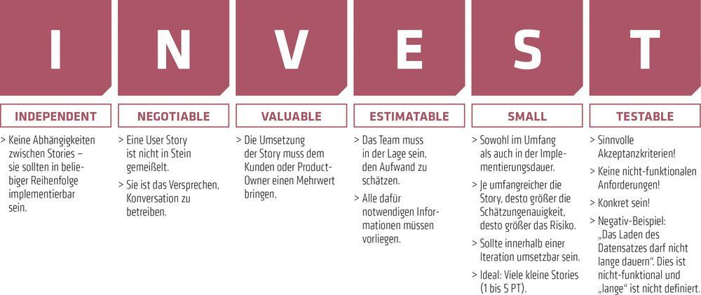

Figure 2: INVEST Kriterien. Quelle: adesso

#### 1.2.2.2 Anforderungen: Template zur Beschreibung von Anforderungen nach Die SOPHISTen (2019)

FunktionMASTeR (Mustergültige Anforderungen - die SOPHIST Template für Requirements). Das Originaldokument ist hier zu finden: functionMASTeR. Die Motivation war es durch Templates (wie es auch die User Story) ist, die Qualität von Anforderungen zu verbessern.

**Anforderungsschablone/Template**

Eine Anforderungsschablone ist ein Bauplan, der die Struktur eines einzelnen Anforderungssatzes festlegt.

Bevor wir zu den Templates bekommen, müssen wir auch die Sprache achten, da die Templates eine Struktur vorgeben und eben nicht einen Lückensatz wie bei einer User Story.

**Sprachliche Regelungen**

- Es werden stets Anforderungen im Aktiv geschrieben.
- Es werden stets Anforderungen als vollständige Sätze geschrieben.
- Die Anforderungen bilden Prozesse mit Hilfe von Vollverben ab.
- Für jedes Prozesswort wird genau ein Anforderungssatz geschrieben.

**Unterschied zwischen User Story und funktionMASTeR**

Der größte Unterschied zu der User Story ist, dass das funktionMASTeR Template die Anforderungen aus der Sicht des Systems formuliert. Die User Story formuliert die Anforderung aus Sicht des Users.

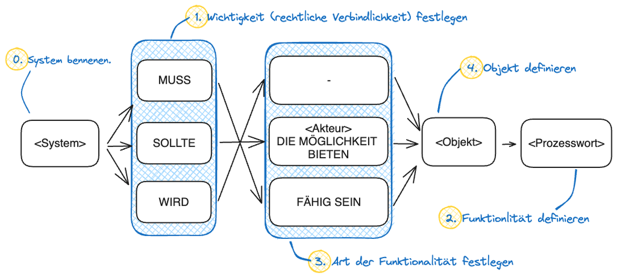

FunktionMASTeR Template Erklärung

Schritte zum Ausfüllen des Templates:

0. Das System ist gegeben. Gebe dem `System` einen Namen.
1. Rechtliche Verbindlichkeit bzw. Wichtigkeit durch die Schlüsselworte *muss, sollte, wird* festlegen
2. Mit dem Prozesswort wird die Funktionalität festgelegt. Das Prozesswort ist technisch ein infinites Verb und nennt damit semantisch die geforderte Funktion.

   ```
   Das Leckage System muss <FUNC> <OBJ> alarmieren.
   ```

3. Die Art der Funktionalität festlegen. Grundsätzliche Unterscheidung nach selbstständige *Systemaktivität, Benutzerinteraktion, Schnittstellenanforderung*. Der `<Akteur>` Wird durch den Benutzer ersetzt.

   ```
   Das Leckage System muss fähig sein <OBJ> alarmieren.
   ```

4. Objekte sind fachlich wert-volle Begriffe im Kontext des betrachteten Gegenstandes.

   ```
   Das Leckage System muss fähig sein die Feuerwehr zu alarmieren.
   ```

##### 1.2.2.2.1 Vertiefung zu den Schlüsselwörtern

Schlüsselwörter nach FunktionsMASTeR zur Abbildung von rechtlicher Verbindlichkeit bei der Formulierung von funktionalen Anforderungen. Die klare und einheitliche Definition etweiliger Schlüsselwörter vereinheitlicht die Wahrnehmung der Verbindlichkeit der Anforderungen.

**Schlüsselwort MUSS**

Alle Anforderungen, die mit MUSS formuliert sind, sind verpflich-tend in der Umsetzung. Die Abnahme eines Produkts kann verweigert werden, sollte das System einer MUSS-Anforderung nicht entsprechen.

**Schlüsselwort SOLLTE**

Formulierungen mit SOLLTE stellen einen Wunsch eines Stake-holders dar. Sie sind nicht verpflichtend und müssen nicht erfüllt werden. Allerdings erhöht ihre Umsetzung die Zufriedenheit der Stakeholder und ihre Dokumentation verbessert die Zusammenarbeit und Kommunikation zwischen Stakeholdern und Entwicklern/Auftragnehmern.

**Schlüsselwort WIRD**

Mit WIRD dokumentieren Sie die Absicht eines Stakeholders. Eine mit WIRD formulierte Anforderung dient als Vorbereitung für eine in der Zukunft liegende Integration einer Funktion. Sie ist verpflichtend in der Umsetzung zu berücksichtigen, auch wenn ihre Realisierung zunächst nicht getestet wird.

##### 1.2.2.2.2 Vertiefung zu Prozesswort und Funktionalität definieren

Es ist sinnvoll eine Liste von Prozessworten zu pflegen und diese zusammen mit der Bedeutung der Worte verfügbar zu machen. Auch in einem Anforderungsdokument.

**Übung Liste für finite Verben**

Nenne finite Verben, die sich besonders gut auf die Domäne Mechatronik und Informatik eignen.

Optional: Nutze die ABC-Methode.

**Lösung Liste für finite Verben (aufgeschrieben nach ABC-Methode)**

Beispielhafte Liste für finite Verben, die sich besonders gut für die Domäne Informatik und Mechatronik eigenen:

A:

- Aktivieren – Funktionen oder Prozesse aktivieren.
- Analysieren – Daten oder Zustände eines Systems analysieren.
- Ausführen – Programme, Algorithmen oder Anweisungen ausführen.

B:

- Berechnen – Ergebnisse oder Zustände mathematisch berechnen.

C:

D:

- Deaktivieren – Funktionen oder Prozesse deaktivieren.

E:

F:

G:

H:

I:

- Implementieren – Algorithmen oder Funktionen in Software umsetzen.
- Integrieren – Komponenten in ein System integrieren.
- Initialisieren – Ein System oder eine Software initialisieren.

J:

K:

- Kalibrieren – Systeme oder Sensoren kalibrieren.
- Kommunizieren – Zwischen Komponenten Daten austauschen.
- Konfigurieren – Einstellungen an einem System oder Gerät vornehmen.

L:

M:

O:

- Optimieren – Prozesse oder Systeme hinsichtlich Effizienz verbessern.

P:

Q:

R:

S:

- Simulieren – Prozesse oder Systeme simulieren.
- Steuern – Ein System oder eine Maschine steuern.
- Synchronisieren – Daten oder Prozesse synchronisieren.

T

U:

- Übertragen – Daten zwischen Geräten übertragen.
- Überwachen – Zustände eines Systems oder Prozesses überwachen.

V:

- Validieren – Daten oder Eingaben überprüfen.
- Verarbeiten – Daten verarbeiten oder Signale analysieren.
- Visualisieren – Daten oder Systemzustände visuell darstellen.

W:

X:

Y:

Z:

##### 1.2.2.2.3 Vertiefung Art der Funktionalität

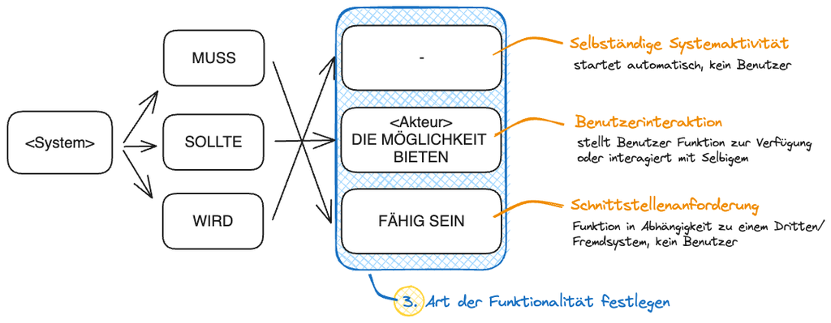

Vertiefung der Art der Funktionalität

##### 1.2.2.2.4 Vertiefung Das Objekt

Welche Worte als Objekte sinnvoll sind, hängt stark vom verwendeten Prozesswort ab. Hier eine beispielhafte Tabelle für mögliche Objekte:

| OBJEKTKANDIDATEN | BEISPIELE |
| --- | --- |
| Greifbare Objekte | Fließband, Temperatursensor, Telefon |
| Rollen, die von Objekten gespielt werden | Pilot, Mitarbeiter, Käufer |
| Objekte, die andere Objekte zusammenfassen | Steuerprogramm, Montageanleitung, Rezept |
| Vorgänge, Geschehnisse | Anruf, Verkauf, Schaltvorgang |

#### 1.2.2.3 Aufgaben

**Aufgabe übergeordnete Anforderungen**

Schreiben Sie 3-5 übergeordnete Anforderungen für das Legoset in Abbildung Figure 1 mit den 3Ws auf.

**Labor-Aufgabe übergeordnete Anforderungen**

Schreiben sie 3-5 Übergeordnete Anforderungen für ihre Implementierung im Labor mit den 3Ws auf.

### 1.2.3 Quality Goals: The key drivers of architecture

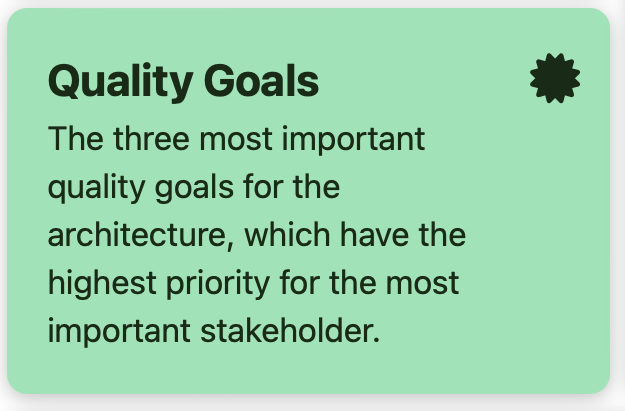

Inception Canvas - Quality Goals

Hier stehen die drei wichtigsten Qualitätsziele für das Softwaresystem. Ebenso wie die übergeordneten Anforderungen werden diese weiter zerlegt.

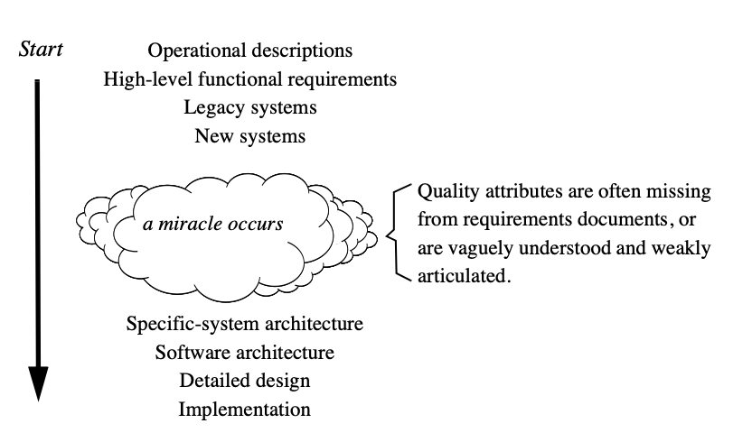

Traditioneller Ansatz im System Design

Qualitätsziele müssen jedem Teammitglied bekannt sein, denn sie prägen Ihre Architektur und das System Design.

Die Norm ISO/IEC 25010 bietet einen Überblick über die Kathegirien von Qualitätszielen.

> Das arc42-Qualitätsmodell (Q42) sammelt mehr als 130 Qualitätsattribute mit umfangreichen Erläuterungen und Beispielen.

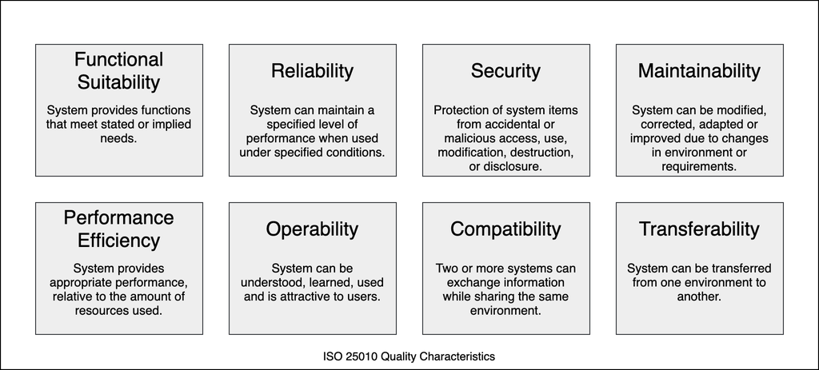

ISO/IEC 25010 Qualitätseigenschaften als Kathegorien von Qualitätszielen

Mit dem Mittel der Quality Scenarios können Qualitätsziele formuliert werden.

> Quality Scenarios werden ausführlich in Kapitel Section 1.3 eingeführt.

**Aufgabe übergeordnete Qualitätsziele**

Schreiben sie 3 Qualitätsziele für das Legoset in Abbildung Figure 1 und ordnen Sie die dieses in die Kathegorien der Norm ISO/IEC 25010.

### 1.2.4 Business Context: Explore the context and get the scope

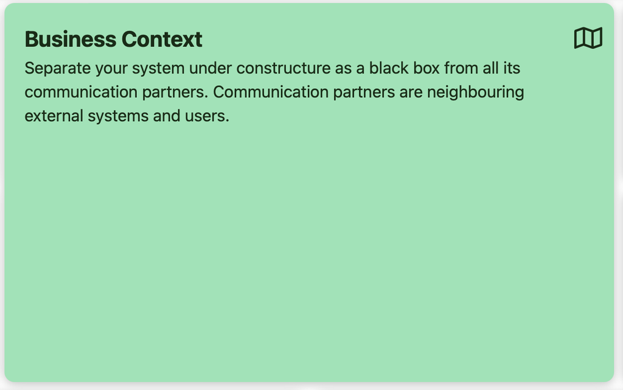

Inception Canvas - Business Context

Der Unternehmenskontext konzentriert sich auf Ihr System als Blackbox. Die Aufmerksamkeit richtet sich auf die Umgebung des Systems und darauf, wie das System mit allen externen Systemen innerhalb des Systems interagiert.

Anhand des geschäftlichen Kontexts können Sie die Kommunikationswege und damit potenzielle technische Risiken ermitteln.

Es ist auch eine gute Möglichkeit, mit verschiedenen Interessengruppen den Umfang des Systems und die Kommunikationswege zu verschiedenen externen Systemen zu besprechen.

Wenn Sie versuchen, den geschäftlichen Kontext zu ermitteln, versuchen Sie, die Benutzer Ihres Systems und aller benachbarten Systeme zu identifizieren.

In diesem Teil müssen Sie eine geschäftsorientierte Kontextsicht erstellen, um eine gemeinsame Sicht auf den geschäftlichen Umfang des Systems zu erhalten. Konzentrieren Sie sich also auf ein gemeinsames Verständnis und nutzen Sie diesen Teil, um ein Werkzeug zu entwickeln, mit dem Sie den Systemkontext anderen Beteiligten innerhalb und außerhalb des Teams vermitteln können.

Dieser geschäftsorientierte Rahmen ist die Grundlage für den späteren technischen Kontext. Hier erarbeiten Sie das Zentrum Ihrer Softwarearchitektur-Aktivitäten.

> UML Use Case Diagramme sind eine gute Möglichkeit diesen Kontext zu visualisieren. Sie fokusieren insbesondere auf die Externen Systeme und Benutzer als Actoren. Diese besprechen wir in einem gesonderten Kapitel.

### 1.2.5 Organisational and Technical Constraints: Your limitation of freedom

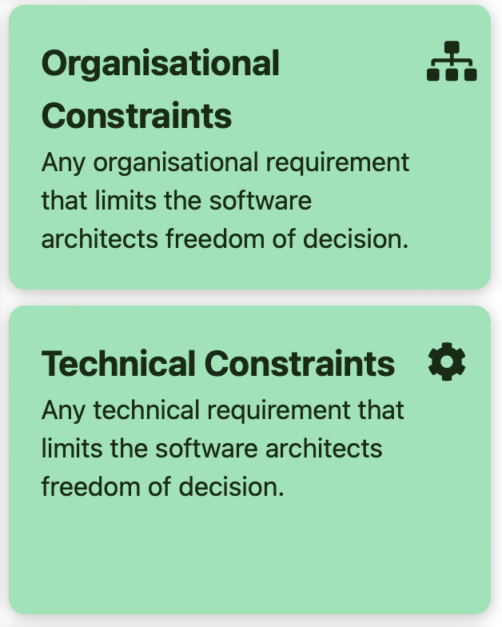

Inception Canvas - Constraints

Organisatorische und technische Rahmenbedingungen bestimmen den Grad Ihrer Entscheidungsfreiheit als Entwicklungsteam.

In diesem Teil erarbeiten Sie alle Anforderungen, die Ihre Freiheit als Produktteam bei der Entwicklung des Softwareprodukts einschränken.

**Organisational constraints**

Zu den organisatorischen Zwängen gehören oft Zeit und Geld. Dazu kommen häufig, dass es Einschränkungen bei den verwendeten Methoden (wie SAFe, Scrum, …) oder Techniken gibt.

Konkrete organsiatorische Rahmenbedingungen in Bezug auf Entwicklungsmethoden:

- Bei der Entwicklung von Fahrzeugsoftware ist der Entwicklungsprozess nach ASPICE vorgeschrieben.
- Um ein einem größeren organisatorischen Kontext zu arbeiten muss ein bestimmte Entwickluingmethodik verwendet werden .z.B. SAFe.

**Technical constraints**

In größeren Unternehmen gibt es oft viele technische Zwänge. Oft gibt es einen übergreifenden Architekturausschuss, der die Standards für die Technologieauswahl festlegt.

For example, if you decide to build a single-page application, the overarching architecture committee will set Angular as the SPA framework, so there are expertise synergies between teams.

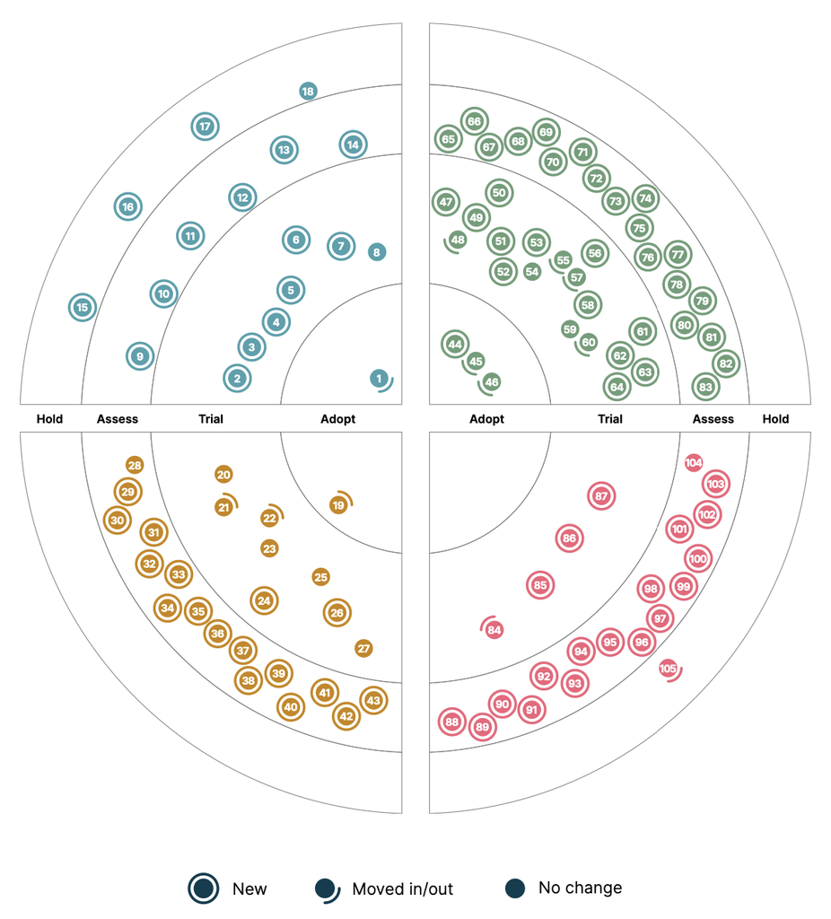

Techradar Quelle: /www.thoughtworks.com

Beispiele sind:

- Alg. [Techradar](https://www.thoughtworks.com/en-de/radar) / [Golden Path](https://engineering.atspotify.com/2020/08/how-we-use-golden-paths-to-solve-fragmentation-in-our-software-ecosystem/) der Unternehmen
- Vorgeschriebene Technologien (z.B. Programmiersprache wegen Kompatibilität oder auch rechtlicher, prozessoaler Anforderungen)
- Fähigkeiten der Mitarbeiter (z.B. Entwicklungsteam programmiert ausschließlich in einer bestimmten Programmiersprache oder Technologie)
- Zielhardware

**Laboraufgabe: technische und organisatorische Rahmenbedingungen**

Schreiben sie die technischen und organisatorischen Rahmenbedinungen für ihre Implementierung auf.

### 1.2.6 Architectural Hypotheses: Create your first high-level architectural hypotheses based on your current knowledge

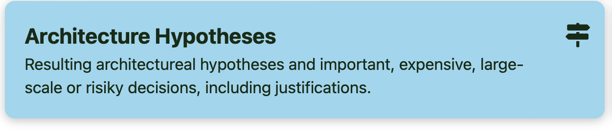

Inception Canvas - Architectural Hypotheses

Die bisherigen Felder im Canvas definieren die architekturelle Spielwiese. Jetzt können Hypothesen basierend auf dem zusammengetragenen Wissen aufgestellt werden.

Eine gute Möglichkeit ist die architekturellen Hypothesen als Architecture Decision Records zu formulieren.

> “Entscheidung” bedeuetet, dass es mehrere Alternativen gibt aus denen gewählt werden kann. Sonst ist es eine technische oder organisatorische Rahmenbedingung.

**Archetecture Decision Records nach Michael Nygard [^1]:**

| Section | Description |
| --- | --- |
| Titel (title) | kurze, den Inhalt des ADR wiedergebende Beschreibung der Entscheidung. |
| Kontext (context) | Beschreibung der Bedingungen, die zu der Entscheidung geführt haben. |
| Entscheidung (decision) | Beschreibung der Entscheidung, die im Rahmen des vorher beschriebenen Kontexts erfolgt ist. |
| Status (status) | Position im Lebenszyklus der Entscheidung wie “proposed”, “accepted”, “discarded”, “deprecated” oder “superseeded”. |
| Konsequenzen (consequences) | Auflistung aller positiven und negativen Konsequenzen. |

Beispiel: 0002-implement-as-shell-script.md

```markdown
# 2. Implement as shell scripts

Date: 2016-02-12

## Status

Accepted

## Context

ADRs are plain text files stored in a subdirectory of the project.

The tool needs to create new files and apply small edits to
the Status section of existing files.

## Decision

The tool is implemented as shell scripts that use standard Unix
tools -- grep, sed, awk, etc.

## Consequences

The tool won't support Windows. Being plain text files, ADRs can
be created by hand and edited in any text editor.  This tool just
makes the process more convenient.

Development will have to cope with differences between Unix
variants, particularly Linux and MacOS X.
```

Weitere Beispiele siehe https://github.com/npryce/adr-tools/tree/master/doc/adr

### 1.2.7 Challenges and Risks: What are the upcoming challenges and the resulting risks?

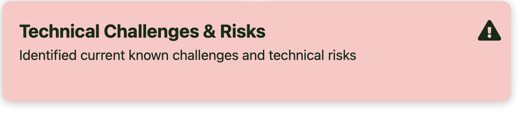

Auf der Grundlage der von Ihnen geschaffenen Spielwiese, wie z. B. Geschäftskontext und -umfang, Qualitätsziele und -beschränkungen, können Sie die anstehenden Herausforderungen und die daraus resultierenden Risiken erfassen.

Es ist sehr wichtig, dies auszuarbeiten, kontinuierlich zu bewerten und den wichtigsten Beteiligten am System mitzuteilen.

Dieser Abschnitt beantwortet die Frage, wie Sie die aktuelle Situation in Bezug auf die ausgearbeitete architektonische Spielwiese bewerten.

### 1.2.8 Complete example of a Inception Canvas

[figure not shown]

Inception Canvas - Techradar

## 1.3 Quality Szenarios

Qualitätsszenarien stellen einen Rahmen für die Definition, Kategorisierung und Messung von Qualitätsanforderungen dar.

Qualitätsanforderungen definieren zusätzliche Eigenschaften eines Softwaresystems neben den funktionalen Anforderungen.

Die Qualitätsanforderungen werden oft als nicht-funktionale Anforderungen bezeichnet. Dieser Begriff ist jedoch irreführend, da die Qualitätsanforderungen einen starken Bezug zur Funktionalität der Domäne haben. Es besteht entweder ein direkter Bezug zu einer oder mehreren Domänenfunktionen (z.B. „die Suchergebnisse sollen in weniger als 200ms dargestellt werden“) oder die Qualitätsanforderung bezieht sich auf einige begleitende Prozesse (z.B. „eine zusätzliche Instanz der Komponente xy startet in weniger als 15s“).

Die Architektur eines Softwaresystems wird durch diese Qualitätsanforderungen erheblich beeinflusst.

**Resources for Quality Requirements**

- [ISO 25010 Sofware Product Quality](https://iso25000.com/index.php/en/iso-25000-standards/iso-25010)
- [arc42 Quality Model](https://quality.arc42.org/)
- [Architecture Characteristics - Fundamentals of Software Architecture](https://medium.com/@biancamagri/summary-chap-4-fundamentals-of-software-architecture-9c5f03063705)

**Quality Scenarios**

Quality Szenarien sind eine einfache Technik: Sie beschreiben, wie ein System auf bestimmte Einflüsse (genannt Events oder Stimuli) reagiert, was beim Eintreffen eines Stimulus auf ein System in bestimmten Situationen geschieht. Dabei müssen wir zwei wesentliche Kategorien differenzieren, nämlich

1. die **Anwendungs- oder Nutzungsszenarien** (beschreiben das Verhalten des Systems bei seiner Nutzung) und
2. die **Änderungsszenarien** (beschreiben, wie das System auf irgendwelche Änderungen reagiert, beispielsweise geänderte Anforderungen oder auch Änderungen in Betriebs- oder Ablaufumgebung).

Beispiele:

| Quality Scenario Type | Example |
| --- | --- |
| Anwendungsszenarien | Die Antwort auf eine Angebotsanfrage muss Endbenutzern im Regelbetrieb in weniger als fünf Sekunden dargestellt werden. Im Betrieb unter hoher Last (z. B. Weihnachtsgeschäft) darf eine Antwort bis zu … |
| Anwendungsszenarien | Benutzer ohne Vorkenntnisse sollen bei der erstmaligen Verwendung des Systems innerhalb von 2 Minuten in der Lage sein, die gewünschte Funktionalität selbstständig zu finden und verwenden zu können. |
| Änderungsszenarien | Die Implementierung eines neuen Versicherungstarifs muss in weniger als 30 Personentagen möglich sein. |

[figure not shown]

Quality Scenraio-schemantic

Based on arc42 quality [^2] and Bass et al. [^3] the elements of a quality scenario are:

**Elements of a quality scenario**

**Stimulus/Event**: Any condition or event arriving at the system.

- How does someone use the system?
- Who is changing what in the system?
- What is the external event?

**Reaction/Response**: The activity undertaken after the arrival of the stimulus.

- What is the response from the system?
- What is the reaction to the user?

**System** (or part): Some artifact is stimulated, which may be the whole system or some distinct pieces (artifacts) of it.

**Metric** (response measure): The response should be measurable in some fashion, so that this scenario (quality requirement) can be objectively assessed or tested.

- A measure regarding the response?

### 1.3.2 Specific Quality Requirements Scenario Tree

It is crucial to define and document the *essential (not all)* quality requirements within a quality workshop as soon as possible together with the functional requirements. Below is an example of a specific quality tree. The leaves of this tree are the quality scenarios and the inner-nodes are the quality features.

[figure not shown]

Quality Scenario Tree

**Definitions of the Quality Features (en)**

This section introduces descriptions of the **essential** quality features for a common understanding. Furthermore it lists further quality features with high relevance.

Definitions might be overlapping and especially there is no exhausting list of architectural features.

The quality features are categorized into operational, structural and cross-functional features.

##### 1.3.2.0.1 Operational Quality Features

- **Availability**: How long does the system need to be available (for 24/7 operations: measures are needed to quickly restart the system in case of an error)?
- **Continuity**: The ability to recover from an emergency.
- **Performance**: This includes stress tests, analysis of performance peaks, frequency of use of certain functions, required capacities, and response times. The decline in performance is a separate area that sometimes takes months on its own

Additional operational requirement features are:

- **Recoverability**: Requirements to ensure operation (how quickly must a system be available again in an emergency?). This affects the backup strategy, deployment process and the need for duplicated hardware.
- **Reliability**: Determine whether the system needs to be fail-safe or if it is so mission-critical that human lives are at stake. Will a failure cost the company a large amount of money?
- **Robustness**: The ability to handle errors and boundary situations, with the system continuing to run even if there is no internet connection or if there are power or hardware failures.
- **Scalability**: The ability of a system to continue functioning even when the number of users or requests increases.

##### 1.3.2.0.2 Structural Quality Features

- **Configurability**: The ability for (end-)users to easily customize parts of the software configuration (via usable interfaces).
- **Extensibility**: How important it is to add new functionalities?
- **Portability**: The ease with which a system can be installed on different platforms as well as the ability to reuse components for different applications.

Additional structural quality features are localization and usability.

##### 1.3.2.0.3 Cross-Cutting Quality Features

Additional cross-function quality features are: legal quality features, interoperability, ability to learn, and privacy.

**Definition of Quality Features (de)**

In diesem Abschnitt werden Beschreibungen der **wesentlichen** Qualitätsmerkmale für ein gemeinsames Verständnis vorgestellt. Darüber hinaus werden weitere Qualitätsmerkmale mit hoher Relevanz aufgeführt.

**Important**

Die Definitionen können sich überschneiden und insbesondere gibt es keine abschließende Liste von Architekturmerkmalen.

Die Qualitätsmerkmale werden in operative, strukturelle und funktionsübergreifende Merkmale eingeteilt.

##### 1.3.2.0.4 Operational Quality Features

**Verfügbarkeit (availability)**

> Wie lange muss das System verfügbar sein (für 24/7 werden Maßnahmen gebraucht, mit denen das System bei einem Fehler schnell wieder hochgefahren werden kann)?

**Beständigkeit (continuity)**

> Die Fähigkeit, sich von einem Notfall zu erholen.

**Performance**

> Hierzu gehören Stresstests, eine Analyse von Leistungsspitzen, der Häufigkeit, mit der bestimmte Funktionen genutzt werden, welche Kapazitäten gebraucht werden, und Antwortzeiten. Die Abnahme der Performance ist ein eigener Bereich, der manchmal allein schon Monate braucht.

**Wiederherstellbarkeit (recoverability)**

> Anforderungen, um den Betrieb sicherzustellen (wie schnell muss ein System im Notfall wieder verfügbar sein?). Das hat Einfluss auf die Backupstrategie und den Bedarf an duplizierter Hardware.

**Verlässlichkeit/Sicherheit (reliability/security)**

> Feststellen, ob das System ausfallsicher sein muss oder ob es so missionskritisch ist, dass Menschenleben auf dem Spiel stehen. Wird ein Ausfall das Unternehmen eine große Menge Geld kosten?

**Robustheit (robustness)**

> Die Fähigkeit, mit Fehlern und Grenzsituationen umzugehen, wobei das System weiterläuft, auch wenn es keine Internetverbindung gibt oder es zu Strom- oder Hardwareausfällen kommt.

**Skalierbarkeit (scalability)**

> Die Fähigkeit eines Systems, auch dann noch zu funktionieren, wenn die Zahl der Nutzer oder Anfragen steigt

Architekten müssen sich auch mit der Codestruktur befassen. Oftmals hat der Architekt die alleinige, zumindest aber eine Teilverantwortung für die Codequalität.

##### 1.3.2.0.5 Structural Quality Features

**Konfigurierbarkeit**

> Die Möglichkeit für Endbenutzer, Teile der Softwarekonfiguration auf einfache Weise (über benutzbare Schnittstellen) anzupassen

**Erweiterbarkeit**

> Wie wichtig es ist, neue Funktionalitäten hinzuzufügen.

**Installierbarkeit**

> Die Leichtigkeit, mit der ein System auf verschiedenen Plattformen installiert werden kann

**Nutzbarkeit/Wiederverwendung**

> Die Fähigkeit, häufig verwendete Komponenten in mehreren Produkten einzusetzen.

**Lokalisierung**

> Unterstützung für Mehrsprachigkeit für Eingabe/Abfrageschnittstellen in Datenfeldern; Anforderungen für Multibyte-Zeichen; Maßeinheiten und Währungen

Viele architektonische Eigenschaften können nur schwer bestimmten Kategorien zugeordnet werden. Trotzdem haben sie großen Einfluss auf das Design. Einige dieser Einschränkungen und Überlegungen sind:

**Zugänglichkeit**

> Zugriff für alle Benutzer inklusive derer mit Einschränkungen wie Farbenblindheit oder Hörverlust

**Archivierbarkeit**

> Werden die Daten nach einer bestimmten Zeit archiviert oder gelöscht? (Kundenkonten könnten beispielsweise nach drei Monaten gelöscht oder als obsolet markiert und in einer Sekundärdatenbank für spätere Zugriffe gespeichert werden.

##### 1.3.2.0.6 Cross-Cutting Quality Features

**Authentifizierung**

> Sicherheitsanforderungen, um die Identität der Nutzer festzustellen und zu überprüfen

**Authorisierung**

> Sicherheitsanforderungen, um sicherzustellen, dass Nutzer nur auf bestimmte Funktionen der Applikation zugreifen können (nach Anwendungsfall, Subsystem, Webseite, Business-Regel, Field Level und so weiter)

**Rechtliches**

> Unter welchen rechtlichen Beschränkungen wird das System betrieben (Datenschutz, Sarbanes Oxley, DSGVO und so weiter)? Welche Vorbehaltsrechte braucht das Unternehmen? Irgendwelche Regelungen, die beeinflussen, wie die Applikation erstellt bzw. bereitgestellt wird?

**Privatsphäre**

> Die Möglichkeit, Transaktionen vor internen Mitarbeitern des Unternehmens zu verstecken (verschlüsselte Transaktionen, sodass nicht einmal DBAs oder Netzwerkarchitekten sie sehen können).

**Sicherheit**

> Müssen die Daten in der Datenbank verschlüsselt werden? Ist eine Verschlüsselung für die Kommunikation zwischen internen Systemen nötig? Welche Art der Authentifizierung wird für entfernten Benutzerzugriff gebraucht?

**Usability/Erreichbarkeit**

> Welcher Trainingsaufwand ist nötig, damit Nutzer ihre Ziele mit der Lösung/Applikation erreichen können? Anforderungen an die Benutzbarkeit müssen genauso ernst genommen werden wie alle anderen architektonischen Belange auch.

More Features are:

- Lernfähigkeit
- Interoperabilität

### 1.3.3 Example: agv master control system quality scenarios

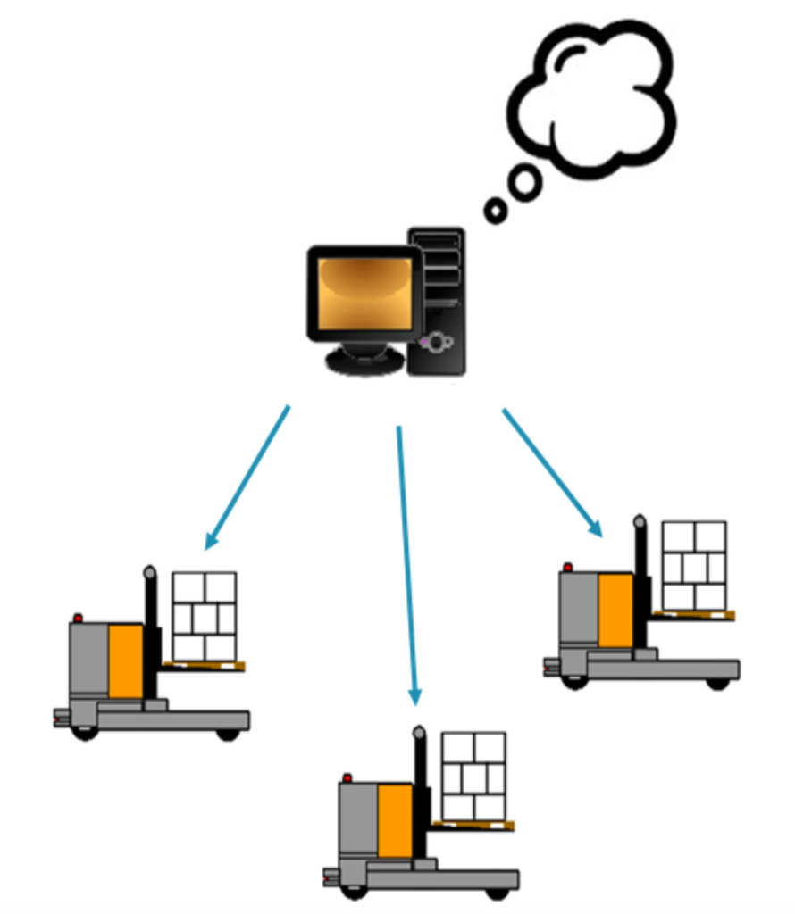

(a) Overview

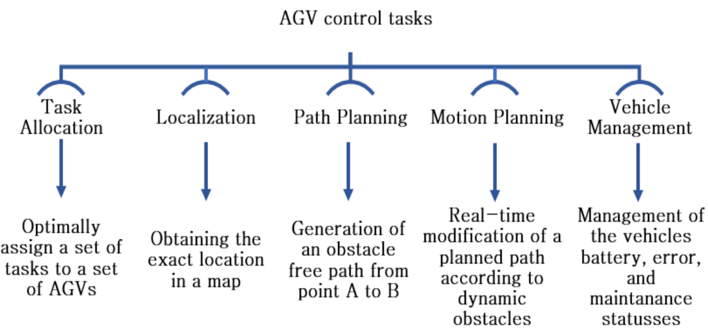

(b) Task

Figure 3: Example System: AGV master contorl system (vgl. De Ryck, Versteyhe, and Debrouwere (2020))

The following table contains a collection of the quality scenarios for the agv master control system project (Figure 3), as well as approaches and strategies to resolve these within the architecture:

[output not shown]

## 1.4 Quality Measures mit Fitnessfunktionen

Fitnessfunktionen sind eine Sichtweise von bereits vorhandenen Werkzeugen.

**Architektonische Fitnessfunktion**

Jeder Mechanismus, der eine objektive Bewertung der Integrität einzelner oder Kombinationen bestimmter architektonischer Eigenschaften ermöglicht

Wichtige Werkzeuge zur Verwendung einer Fitnessfunktion

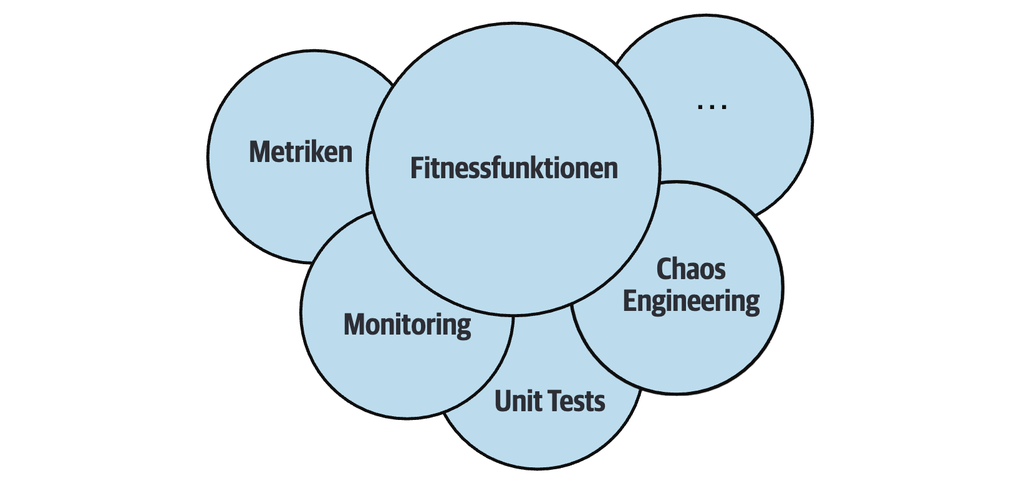

Quelle Richards and Ford (2021)

- Metriken, um arichtektonische Eigenschaften zu testen. (z.B. für Modularität), Metriken für Code Coverage, …
- Monitoring des Systems, hinsichtlich Speicherverbrauch, CPU-Nutzung, Zugriff auf das Dateisystem, …
- (Unit-) Testing
- Chaos Engineering, um die Resilienz eines Systems für unvorhergesehene Situationen zu testen

## 1.6 Quellen

Bass, Len, Paul Clements, and Rick Kazman. 2021. *Software Architecture in Practice, 4th Edition*. 4th ed. Addison-Wesley Professional. https://www.oreilly.com/library/view/software-architecture-in/9780136885979/.

De Ryck, M., M. Versteyhe, and F. Debrouwere. 2020. “Automated Guided Vehicle Systems, State-of-the-Art Control Algorithms and Techniques.” *Journal of Manufacturing Systems* 54 (January): 152–73. https://doi.org/10.1016/j.jmsy.2019.12.002.

Die SOPHISTen. 2019. “Schablonen Für Alle Fälle.” SOPHIST GmbH. www.sophist.de.

Richards, Mark, and Neal Ford. 2021. *Handbuch Moderner Softwarearchitektur: Architekturstile, Patterns Und Best Practices*. Translated by Jørgen W. Lang. 1. Auflage. Heidelberg: O’Reilly.

## Footnotes

[^1]: [documenting-architecture-decisions](https://cognitect.com/blog/2011/11/15/documenting-architecture-decisions.html)
[^2]: [Quality arc 42 - how to specify requirements](https://quality.arc42.org/articles/specify-quality-requirements)
[^3]: Bass, Clements, and Kazman (2021)